# Aplicación 1.2: Exploración de datos

- Show All Code
- Hide All Code
- View Source

# Comparación de los lenguajes R y Python

En esta aplicación se usarán las librerías estándar de R y Python para explorar la base de datos seleccionada, replicando los resultados con los correspondientes comandos en ambos lenguajes.

En concreto, para el lenguaje R se utilizará la colección de librerías contenidas en el paquete `tidyverse` (https://www.tidyverse.org/packages/), y para Python se usarán las librerías `numpy` (https://numpy.org/), `pandas` (https://pandas.pydata.org/), `matplotlib` (https://matplotlib.org/) y `seaborn` (https://seaborn.pydata.org/). Las librerías especializadas en estadística y econometría se verán en aplicaciones posteriores.

**Código R**

## Lectura de librerías

```r
library(tidyverse)
# Datos de la aplicación:  base de datos palmerpenguins
# (https://allisonhorst.github.io/palmerpenguins/)
library(palmerpenguins)
```

## Lectura de datos

```r
data("penguins")
df <- penguins
df %>%
  head()
```

```
# A tibble: 6 × 8
  species island    bill_length_mm bill_depth_mm flipper_length_mm body_mass_g
  <fct>   <fct>              <dbl>         <dbl>             <int>       <int>
1 Adelie  Torgersen           39.1          18.7               181        3750
2 Adelie  Torgersen           39.5          17.4               186        3800
3 Adelie  Torgersen           40.3          18                 195        3250
4 Adelie  Torgersen           NA            NA                  NA          NA
5 Adelie  Torgersen           36.7          19.3               193        3450
6 Adelie  Torgersen           39.3          20.6               190        3650
# ℹ 2 more variables: sex <fct>, year <int>
```

## Análisis exploratorio

Recuento de los NAs en cada columna

```r
df %>%
  summarize(across(.cols = everything(),
                   ~sum(is.na(.x)))) %>%
  pivot_longer(cols = everything())
```

```
# A tibble: 8 × 2
  name              value
  <chr>             <int>
1 species               0
2 island                0
3 bill_length_mm        2
4 bill_depth_mm         2
5 flipper_length_mm     2
6 body_mass_g           2
7 sex                  11
8 year                  0
```

Para eliminar todas las filas con un NA habría que ejecutar el siguiente código

```r
# df <- df %>% na.omit()
```

Número de especies

```r
df %>%
  count(species, sort = TRUE)
```

```
# A tibble: 3 × 2
  species       n
  <fct>     <int>
1 Adelie      152
2 Gentoo      124
3 Chinstrap    68
```

Número de islas

```r
df %>%
  count(island, sort = TRUE)
```

```
# A tibble: 3 × 2
  island        n
  <fct>     <int>
1 Biscoe      168
2 Dream       124
3 Torgersen    52
```

Número de especies en cada isla

```r
df %>%
  count(species, island, sort = TRUE)
```

```
# A tibble: 5 × 3
  species   island        n
  <fct>     <fct>     <int>
1 Gentoo    Biscoe      124
2 Chinstrap Dream        68
3 Adelie    Dream        56
4 Adelie    Torgersen    52
5 Adelie    Biscoe       44
```

Tabla 3x3 de recuento de especies por isla

```r
table(species = df$species,
      island = df$island)
```

```
           island
species     Biscoe Dream Torgersen
  Adelie        44    56        52
  Chinstrap      0    68         0
  Gentoo       124     0         0
```

Tabla 3x3 de proporciones de especies por isla

```r
table(species = df$species,
      island = df$island) / nrow(df)
```

```
           island
species        Biscoe     Dream Torgersen
  Adelie    0.1279070 0.1627907 0.1511628
  Chinstrap 0.0000000 0.1976744 0.0000000
  Gentoo    0.3604651 0.0000000 0.0000000
```

Gráfico de barras de especies

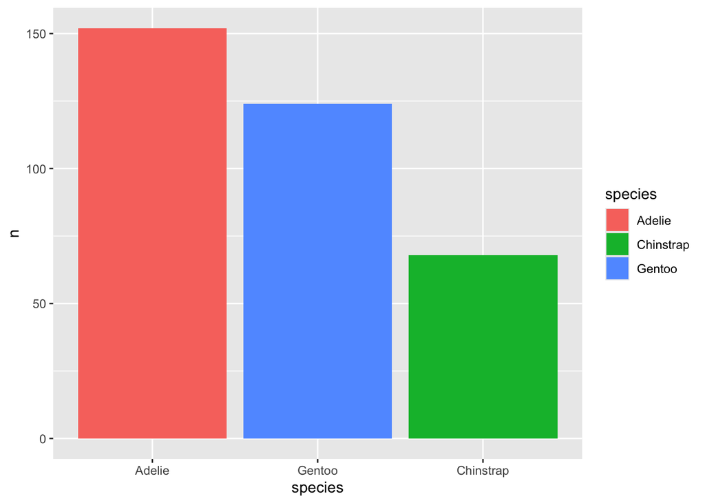

```r
df %>%
  count(species, sort = TRUE) %>%
  ggplot(aes(x = reorder(species, -n), y = n)) +
  geom_col(aes(fill = species)) +
  xlab('species')
```

Descripción de todas la columnas de la base de datos

```r
summary(df)
```

```
      species          island    bill_length_mm  bill_depth_mm
 Adelie   :152   Biscoe   :168   Min.   :32.10   Min.   :13.10
 Chinstrap: 68   Dream    :124   1st Qu.:39.23   1st Qu.:15.60
 Gentoo   :124   Torgersen: 52   Median :44.45   Median :17.30
                                 Mean   :43.92   Mean   :17.15
                                 3rd Qu.:48.50   3rd Qu.:18.70
                                 Max.   :59.60   Max.   :21.50
                                 NA's   :2       NA's   :2
 flipper_length_mm  body_mass_g       sex           year
 Min.   :172.0     Min.   :2700   female:165   Min.   :2007
 1st Qu.:190.0     1st Qu.:3550   male  :168   1st Qu.:2007
 Median :197.0     Median :4050   NA's  : 11   Median :2008
 Mean   :200.9     Mean   :4202                Mean   :2008
 3rd Qu.:213.0     3rd Qu.:4750                3rd Qu.:2009
 Max.   :231.0     Max.   :6300                Max.   :2009
 NA's   :2         NA's   :2
```

Cálculo de la media de la longitud y la profundidad del pico

```r
df %>%
  select(bill_length_mm, bill_depth_mm) %>%
  summarize(across(.cols = everything(),
                   ~mean(.x, na.rm = TRUE)))
```

```
# A tibble: 1 × 2
  bill_length_mm bill_depth_mm
           <dbl>         <dbl>
1           43.9          17.2
```

Cálculo de los cuantiles 25, 50 y 75 para la longitud y profundidad del pico en la Isla Biscoe

```r
df %>%
  filter(island == "Biscoe") %>%
  select(bill_length_mm, bill_depth_mm) %>%
  summarize(length25 = quantile(bill_length_mm, probs = 0.25, na.rm = TRUE),
            length50 = quantile(bill_length_mm, probs = 0.50, na.rm = TRUE),
            length75 = quantile(bill_length_mm, probs = 0.75, na.rm = TRUE),
            depth25 = quantile(bill_depth_mm, probs = 0.25, na.rm = TRUE),
            depth50 = quantile(bill_depth_mm, probs = 0.50, na.rm = TRUE),
            depth75 = quantile(bill_depth_mm, probs = 0.75, na.rm = TRUE))
```

```
# A tibble: 1 × 6
  length25 length50 length75 depth25 depth50 depth75
     <dbl>    <dbl>    <dbl>   <dbl>   <dbl>   <dbl>
1       42     45.8     48.7    14.5    15.5      17
```

Diagrama de cajas (boxplot) vertical de la longitud del pico por especie

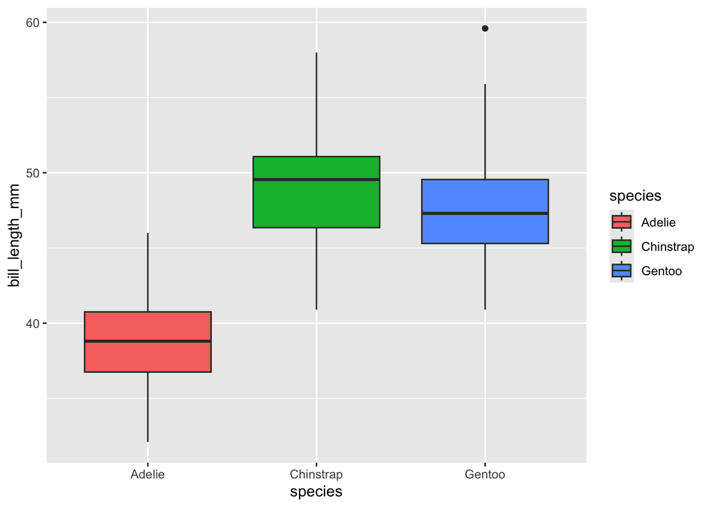

```r
df %>%
  ggplot(aes(x = species, y = bill_length_mm, fill = species)) +
  geom_boxplot()
```

Boxplot horizontal